# Johns Hopkins’ Covid-19 Data EDA

Cody Hill

2023-04-25

## Setup

Note, before using knitr please install all missing packages from the code cell below into your environment.

Also, I recommended knitting into HTML as it has been optimized for viewing in that format.

R Packages used:

- library(tidyverse)
- library(lubridate)
- library(ggplot2)
- library(usmap)
- library(viridis)
- library(forecast)

Please use install.packages(‘…’) to install any you may have missing.

If you have trouble knitting due to issues installing these packages you can view the knitted version by:

From the repository >> JH_Covid19_EDA.html >> Download(view raw) >> Right click anywhere >> Save As… >> Open

Repository Link: https://github.com/chill0121/JH-Covid19-EDA

*For more technical information about the environment was run on, see the bottom for `sessionInfo()`.*

### Data Source Information

**“COVID-19 Data Repository by the Center for Systems Science and Engineering (CSSE) at Johns Hopkins University”**

This data was procured from https://github.com/CSSEGISandData/COVID-19 where Johns Hopkins has generously compiled covid-19 data.

- This repository stopped updating on 3/10/23.
- In this report we are specifically looking at the `./csse_covid_19_data/csse_covid_19_time_series` data.

I encourage all who reads this report to go read the `readme.md` file in the source’s repository to gain more insights about where this data was collected, how it was validated, and compiled into this dataset. In short, the US data was collected from individual state and county Departments of Health and the global data was collected from various government bodies within each country, with a few exceptions.

*This data set is licensed under the Creative Commons Attribution 4.0 International (CC BY 4.0) by the Johns Hopkins University on behalf of its Center for Systems Science in Engineering.*

*Copyright Johns Hopkins University 2020.*

#### Feature Descriptions from Source

- **FIPS:** US only. Federal Information Processing Standards code that uniquely identifies counties within the USA.
- **Admin2:** County name. US only.
- **Province_State:** Province, state or dependency name.
- **Country_Region:** Country, region or sovereignty name. The names of locations included on the Website correspond with the official designations used by the U.S. Department of State.
- **Lat and Long_:** Dot locations on the dashboard. All points (except for Australia) shown on the map are based on geographic centroids, and are not representative of a specific address, building or any location at a spatial scale finer than a province/state. Australian dots are located at the centroid of the largest city in each state.
- **Cases:** Counts include confirmed and probable (where reported).
- **Deaths:** Counts include confirmed and probable (where reported).
- **UID:** Unique Identifier for each row entry.
- **ISO3:** Officially assigned country code identifiers.

### Environment Setup

**First we will import the libraries in R that are needed.** **We will also import the data using a URL directly from the source repository, this means it will update along with any updates to the repository anytime we reknit.**

```r
# Output all commands run and set a standard plot size
knitr::opts_chunk$set(echo = TRUE, fig.width = 10, fig.height = 6)
# Import Libraries
library(tidyverse)
library(lubridate)
library(ggplot2)
library(usmap)
library(viridis)
library(forecast)
# Import dataset
us_cases <- read.csv("https://github.com/CSSEGISandData/COVID-19/raw/master/csse_covid_19_data/csse_covid_19_time_series/time_series_covid19_confirmed_US.csv")#, fill = TRUE)
us_deaths <- read.csv("https://github.com/CSSEGISandData/COVID-19/raw/master/csse_covid_19_data/csse_covid_19_time_series/time_series_covid19_deaths_US.csv")#, fill = TRUE)
global_cases <- read.csv("https://github.com/CSSEGISandData/COVID-19/raw/master/csse_covid_19_data/csse_covid_19_time_series/time_series_covid19_confirmed_global.csv")#, fill = TRUE)
global_deaths <- read.csv("https://github.com/CSSEGISandData/COVID-19/raw/master/csse_covid_19_data/csse_covid_19_time_series/time_series_covid19_deaths_global.csv")#, fill = TRUE)
```

## Initial Look at the Data

**Let’s check the dimensions of the imported data and output the first few rows in their raw form to decide what needs to be done.**

```r
dim(us_cases)
```

```
## [1] 3342 1154
```

```r
dim(us_deaths)
```

```
## [1] 3342 1155
```

```r
dim(global_cases)
```

```
## [1]  289 1147
```

```r
dim(global_deaths)
```

```
## [1]  289 1147
```

```r
head(us_deaths[1:14])
```

```
##        UID iso2 iso3 code3 FIPS  Admin2 Province_State Country_Region      Lat
## 1 84001001   US  USA   840 1001 Autauga        Alabama             US 32.53953
## 2 84001003   US  USA   840 1003 Baldwin        Alabama             US 30.72775
## 3 84001005   US  USA   840 1005 Barbour        Alabama             US 31.86826
## 4 84001007   US  USA   840 1007    Bibb        Alabama             US 32.99642
## 5 84001009   US  USA   840 1009  Blount        Alabama             US 33.98211
## 6 84001011   US  USA   840 1011 Bullock        Alabama             US 32.10031
##       Long_         Combined_Key Population X1.22.20 X1.23.20
## 1 -86.64408 Autauga, Alabama, US      55869        0        0
## 2 -87.72207 Baldwin, Alabama, US     223234        0        0
## 3 -85.38713 Barbour, Alabama, US      24686        0        0
## 4 -87.12511    Bibb, Alabama, US      22394        0        0
## 5 -86.56791  Blount, Alabama, US      57826        0        0
## 6 -85.71266 Bullock, Alabama, US      10101        0        0
```

```r
head(global_deaths[1:6])
```

```
##   Province.State Country.Region       Lat     Long X1.22.20 X1.23.20
## 1                   Afghanistan  33.93911 67.70995        0        0
## 2                       Albania  41.15330 20.16830        0        0
## 3                       Algeria  28.03390  1.65960        0        0
## 4                       Andorra  42.50630  1.52180        0        0
## 5                        Angola -11.20270 17.87390        0        0
## 6                    Antarctica -71.94990 23.34700        0        0
```

*Slicing the output here so we don’t see all 1100 date columns.*

- Here we can see each date is in an individual column (feature).
- `us_deaths` has an extra `Population` feature. We’ll deal with that when we merge the two tables.
- The dataset starts reporting Covid-19 information on January, 22, 2020.
- The global and US datasets span the same dates but neither global sets include population.

## Cleaning and Transformation Stage

**To clean up these datasets we will do the following:**

US Data:

- Pivot the date columns into rows.
- Merge the cases and deaths datasets, keeping population.

Global Data:

- Pivot the date columns into rows.
- Merge the cases and death datasets.
- Import population data for each country and add a population column.

Also, in both datasets:

- Remove redundant features as well as several that we won’t be using (e.g. `iso2`, `iso3`, `code3`, `Combined_key`).
- Rename a few features for consistency and readability.
- Transform feature class types for easier analysis.
- Check for duplicates and missing entries, NA, Null etc..

### Cleaning US Datasets

```r
# US_Deaths transformations
us_deaths <- us_deaths %>%
    # Pivot all the date columns
    pivot_longer(., -c('UID', 'iso2', 'iso3', 'code3', 'FIPS', 'Admin2', 'Province_State', 'Country_Region', 'Lat', 'Long_', 'Combined_Key', 'Population'),
        names_to = 'Date',
        values_to = 'Deaths') %>%
    # Remove unnecessary features
    select(., -iso2, -iso3, -code3, -Combined_Key) %>%
    # Rename some features
    rename(., County = 'Admin2',
        Long = 'Long_',
        fips = 'FIPS')

# US_Cases transformations
us_cases <- us_cases %>%
    # Pivot all the date columns
    pivot_longer(., -c('UID', 'iso2', 'iso3', 'code3', 'FIPS', 'Admin2', 'Province_State', 'Country_Region', 'Lat', 'Long_', 'Combined_Key'),
        names_to = 'Date',
        values_to = 'Cases') %>%
    # Remove unnecessary features
    select(., -iso2, -iso3, -code3, -Combined_Key) %>%
    # Rename some features
    rename(., County = 'Admin2',
        Long = 'Long_',
        fips = 'FIPS')

# Merge into one dataframe
us_data <- full_join(us_cases, us_deaths)
```

[output not shown]

```r
# Remove the X in the dates and mutate to Date class
us_data$Date <- gsub('X', '', as.character(us_data$Date))
us_data <- us_data %>%
    mutate(Date = mdy(Date))

# Change character classes and UID into factors
us_data <- us_data %>%
        mutate(across(where(is.character), as.factor)) %>%
        mutate(UID = as.factor(UID))

# Display changes
head(us_data)
```

```
## # A tibble: 6 × 11
##   UID     fips County Province_State Country_Region   Lat  Long Date       Cases
##   <fct>  <dbl> <fct>  <fct>          <fct>          <dbl> <dbl> <date>     <int>
## 1 84001…  1001 Autau… Alabama        US              32.5 -86.6 2020-01-22     0
## 2 84001…  1001 Autau… Alabama        US              32.5 -86.6 2020-01-23     0
## 3 84001…  1001 Autau… Alabama        US              32.5 -86.6 2020-01-24     0
## 4 84001…  1001 Autau… Alabama        US              32.5 -86.6 2020-01-25     0
## 5 84001…  1001 Autau… Alabama        US              32.5 -86.6 2020-01-26     0
## 6 84001…  1001 Autau… Alabama        US              32.5 -86.6 2020-01-27     0
## # ℹ 2 more variables: Population <int>, Deaths <int>
```

Pivoting the dates and merging cases and death data into one dataset will make analysis much easier.

### Cleaning Global Datasets

**Now let’s do a similar procedure with the global data, keeping all shared features consistent.**

```r
# Global_deaths transformations
global_deaths <- global_deaths %>%
    # Pivot all the date columns
    pivot_longer(., -c('Province.State', 'Country.Region', 'Lat', 'Long'),
        names_to = 'Date',
        values_to = 'Deaths') %>%
    # Rename some features
    rename(., Province_State = 'Province.State',
        Country_Region = 'Country.Region')

# Global_Cases transformations
global_cases <- global_cases %>%
    # Pivot all the date columns
    pivot_longer(., -c('Province.State', 'Country.Region', 'Lat', 'Long'),
        names_to = 'Date',
        values_to = 'Cases') %>%
    # Rename some features
    rename(., Province_State = 'Province.State',
        Country_Region = 'Country.Region')

# Merge into one dataframe
global_data <- full_join(global_cases, global_deaths)
# Remove the X in the dates and mutate to Date class
global_data$Date <- gsub('X', '', as.character(global_data$Date))
global_data <- global_data %>%
    mutate(Date = mdy(Date))

# Display changes
head(global_data)
```

```
## # A tibble: 6 × 7
##   Province_State Country_Region   Lat  Long Date       Cases Deaths
##   <chr>          <chr>          <dbl> <dbl> <date>     <int>  <int>
## 1 ""             Afghanistan     33.9  67.7 2020-01-22     0      0
## 2 ""             Afghanistan     33.9  67.7 2020-01-23     0      0
## 3 ""             Afghanistan     33.9  67.7 2020-01-24     0      0
## 4 ""             Afghanistan     33.9  67.7 2020-01-25     0      0
## 5 ""             Afghanistan     33.9  67.7 2020-01-26     0      0
## 6 ""             Afghanistan     33.9  67.7 2020-01-27     0      0
```

**Now because we will be interested in making some per capita comparisons in the future, let’s import population data and add it to each country in `global_data`.** **This data was also in the Johns Hopkins repository in a separate lookup table we will import here.**

```r
# Import Table with Populations
UID_Table <- read.csv('https://github.com/CSSEGISandData/COVID-19/raw/master/csse_covid_19_data/UID_ISO_FIPS_LookUp_Table.csv')
head(UID_Table)
```

```
##   UID iso2 iso3 code3 FIPS Admin2 Province_State Country_Region       Lat
## 1   4   AF  AFG     4   NA                          Afghanistan  33.93911
## 2   8   AL  ALB     8   NA                              Albania  41.15330
## 3  10   AQ  ATA    10   NA                           Antarctica -71.94990
## 4  12   DZ  DZA    12   NA                              Algeria  28.03390
## 5  20   AD  AND    20   NA                              Andorra  42.50630
## 6  24   AO  AGO    24   NA                               Angola -11.20270
##      Long_ Combined_Key Population
## 1 67.70995  Afghanistan   38928341
## 2 20.16830      Albania    2877800
## 3 23.34700   Antarctica         NA
## 4  1.65960      Algeria   43851043
## 5  1.52180      Andorra      77265
## 6 17.87390       Angola   32866268
```

```r
# Merge population in using left_join
global_data <- global_data %>%
    left_join(UID_Table, by = c('Province_State', 'Country_Region', 'Lat')) %>%
    select(-c(UID, iso2, iso3, code3, FIPS, Admin2, Combined_Key, Long_))

# Change character classes into factors
global_data <- global_data %>%
        mutate(across(where(is.character), as.factor))
```

**Finally, we should take a look at a summary of our two datasets and see if we can make any high level conclusions.**

```r
summary(us_data)
```

```
##        UID               fips              County         Province_State
##  16      :   1143   Min.   :   60   Unassigned:  59436   Texas   : 292608
##  316     :   1143   1st Qu.:19076   Washington:  35433   Georgia : 184023
##  580     :   1143   Median :31012   Jefferson :  29718   Virginia: 154305
##  850     :   1143   Mean   :33043   Franklin  :  28575   Kentucky: 139446
##  63072001:   1143   3rd Qu.:47130   Jackson   :  27432   Missouri: 134874
##  63072003:   1143   Max.   :99999   Lincoln   :  27432   Kansas  : 122301
##  (Other) :3813048   NA's   :11430   (Other)   :3611880   (Other) :2792349
##  Country_Region      Lat              Long              Date
##  US:3819906     Min.   :-14.27   Min.   :-174.16   Min.   :2020-01-22
##                 1st Qu.: 33.90   1st Qu.: -97.81   1st Qu.:2020-11-02
##                 Median : 38.01   Median : -89.49   Median :2021-08-15
##                 Mean   : 36.72   Mean   : -88.64   Mean   :2021-08-15
##                 3rd Qu.: 41.58   3rd Qu.: -82.31   3rd Qu.:2022-05-28
##                 Max.   : 69.31   Max.   : 145.67   Max.   :2023-03-09
##
##      Cases           Population           Deaths
##  Min.   :  -3073   Min.   :       0   Min.   :  -82.0
##  1st Qu.:    330   1st Qu.:    9917   1st Qu.:    4.0
##  Median :   2272   Median :   24892   Median :   37.0
##  Mean   :  14088   Mean   :   99604   Mean   :  186.9
##  3rd Qu.:   8159   3rd Qu.:   64979   3rd Qu.:  122.0
##  Max.   :3710586   Max.   :10039107   Max.   :35545.0
##
```

```r
summary(global_data)
```

```
##                       Province_State          Country_Region
##                              :226314   China         : 38862
##  Alberta                     :  1143   Canada        : 18288
##  Anguilla                    :  1143   United Kingdom: 17145
##  Anhui                       :  1143   France        : 13716
##  Aruba                       :  1143   Australia     :  9144
##  Australian Capital Territory:  1143   Netherlands   :  5715
##  (Other)                     : 98298   (Other)       :227457
##       Lat               Long              Date                Cases
##  Min.   :-71.950   Min.   :-178.12   Min.   :2020-01-22   Min.   :        0
##  1st Qu.:  3.934   1st Qu.: -42.60   1st Qu.:2020-11-02   1st Qu.:      680
##  Median : 21.513   Median :  20.94   Median :2021-08-15   Median :    14429
##  Mean   : 19.719   Mean   :  22.18   Mean   :2021-08-15   Mean   :   959384
##  3rd Qu.: 40.464   3rd Qu.:  90.36   3rd Qu.:2022-05-28   3rd Qu.:   228517
##  Max.   : 71.707   Max.   : 178.06   Max.   :2023-03-09   Max.   :103802702
##  NA's   :2286      NA's   :2286
##      Deaths          Population
##  Min.   :      0   Min.   :6.700e+01
##  1st Qu.:      3   1st Qu.:5.866e+05
##  Median :    150   Median :6.524e+06
##  Mean   :  13380   Mean   :2.736e+07
##  3rd Qu.:   3032   3rd Qu.:2.585e+07
##  Max.   :1123836   Max.   :1.380e+09
##                    NA's   :13716
```

Even with just the initial cleaning and transformations we can see that:

- This data goes from 2020/01/22 to 2023/03/09
- The distribution of cases is heavily right-skewed (positively skewed) which makes sense since now we can see cases and deaths are recorded as a cumulative sum.
- This dataset is fairly robust, tracking a high granularity of countries, given the minimum population is 67.

Looks like there are a few possible issues here as well:

- In the US data the minimum of `Cases` and `Deaths` is showing a negative value
- In the global data there are NAs in `Lat` and `Long`
- In the global data there are NAs in `Population`

**Here we will investigate these issues in order.**

```r
filter(us_data, Cases < 0 | Deaths < 0)
```

```
## # A tibble: 3 × 11
##   UID     fips County Province_State Country_Region   Lat  Long Date       Cases
##   <fct>  <dbl> <fct>  <fct>          <fct>          <dbl> <dbl> <date>     <int>
## 1 84090… 90037 Unass… North Carolina US                 0     0 2022-11-09   -34
## 2 84090… 90045 Unass… South Carolina US                 0     0 2022-05-05 -3073
## 3 84090… 90045 Unass… South Carolina US                 0     0 2022-05-06 -3073
## # ℹ 2 more variables: Population <int>, Deaths <int>
```

Looks to be all from the same 3 entries. Not a significant amount of data, easiest to just drop the rows in this case. Also, since cases and deaths are cumulative sums (rolling total), we aren’t missing much if we do drop them (i.e. we will likely pick up the intended totals in the next valid entry).

**Let’s drop these 3 rows.**

```r
# Before
dim(us_data)
```

```
## [1] 3819906      11
```

```r
# Remove bad entries
us_data <- us_data[us_data$Cases >= 0 | us_data$Deaths >= 0, ]
# After
dim(us_data)
```

```
## [1] 3819903      11
```

We can see here that we’ve successfully removed the 3 bad entries.

**Now for the coordinate data NAs in the global data.**

```r
lat_na = (filter(global_data, global_data$Lat == is.na(Lat)))
unique(lat_na$Province_State)
```

```
## [1] Diamond Princess Grand Princess
## 92 Levels:  Alberta Anguilla Anhui Aruba ... Zhejiang
```

Interesting, this dataset includes the cruise ships that were quarantined for Covid-19 outbreaks. It makes sense there there isn’t coordinate data to go along with these entries. We will leave them alone and be mindful of these NA entries when we use coordinate data.

**Now for the population data NAs.**

```r
# Find index of NAs
which(is.na(global_data$Population))
```

*Output hidden here because it’s too long.*

```r
# Display a few NA examples
global_data[5716,]
```

```
## # A tibble: 1 × 8
##   Province_State Country_Region   Lat  Long Date       Cases Deaths Population
##   <fct>          <fct>          <dbl> <dbl> <date>     <int>  <int>      <int>
## 1 ""             Antarctica     -71.9  23.3 2020-01-22     0      0         NA
```

```r
global_data[326898,]
```

```
## # A tibble: 1 × 8
##   Province_State Country_Region     Lat  Long Date       Cases Deaths Population
##   <fct>          <fct>            <dbl> <dbl> <date>     <int>  <int>      <int>
## 1 ""             Winter Olympics…  39.9  116. 2023-03-09   535      0         NA
```

```r
global_data[121222,]
```

```
## # A tibble: 1 × 8
##   Province_State Country_Region     Lat  Long Date       Cases Deaths Population
##   <fct>          <fct>            <dbl> <dbl> <date>     <int>  <int>      <int>
## 1 ""             Diamond Princess     0     0 2020-03-25   712     10         NA
```

This also looks fine, Antarctica and the 2022 Winter Olympics are certainly interesting entries, and won’t necessarily have a population associated. We will leave these as well and just be mindful of these entries when we do our analysis.

## Visualizations

With the cleaning and transformation of the data complete, let’s begin plotting some feature relationships to get a better sense of the data and hopefully tease out some conclusions.

### Global Data

**First I think it’d be useful to plot the cases and deaths per capita (100,000) per country, scaling our data to population size which will normalize comparisons between countries.**

We’ll only display the top 50 since there are 201 `Country_Regions`.

```r
# Group by Country, and max population (since cases and deaths are cumulative we don't sum)
# Note na.rm = TRUE because otherwise R will throw a max of NA if one is in the set
options(dplyr.summarise.inform = FALSE)
country_totals <- global_data %>%
    group_by(Country_Region) %>%
    summarize(Cases = max(Cases, na.rm = TRUE),
        Deaths = max(Deaths, na.rm = TRUE),
        Population = max(Population, na.rm = TRUE),
        Lat = median(Lat, na.rm = TRUE),
        Long = median(Long, na.rm = TRUE),
        Cases_Per_100k = max(Cases, na.rm = TRUE) / (max(Population, na.rm = TRUE) / 100000),
        Deaths_Per_100k = max(Deaths, na.rm = TRUE) / (max(Population, na.rm = TRUE) / 100000),
        Deaths_Per_Case = max(Deaths, na.rm = TRUE) / max(Cases, na.rm = TRUE))
```

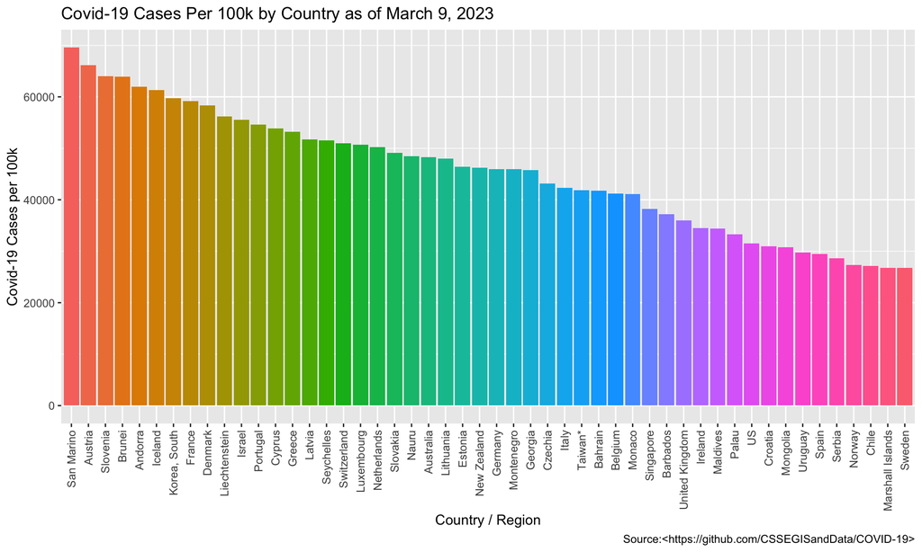

```r
# Sort by per capita in descending order and order the factors for graph order
country_pc_cases <- arrange(country_totals, desc(country_totals$Cases_Per_100k))
country_pc_cases$Country_Region <- fct_inorder(country_pc_cases$Country_Region)

country_pc_deaths <- arrange(country_totals, desc(country_totals$Deaths_Per_100k))
country_pc_deaths$Country_Region <- fct_inorder(country_pc_deaths$Country_Region)

# Plot top 50 cases then deaths per 100k
country_pc_cases_plot <- country_pc_cases[1:50, ] %>%
   ggplot(., aes(x = Country_Region, y = Cases_Per_100k, fill = Country_Region)) +
   geom_bar(stat = 'identity', show.legend = FALSE) +
   theme(axis.text.x = element_text(angle = 90, vjust = 0.5, hjust = 1)) +
   labs(title = 'Covid-19 Cases Per 100k by Country as of March 9, 2023',
        x = 'Country / Region', y = 'Covid-19 Cases per 100k',
        caption = 'Source:<https://github.com/CSSEGISandData/COVID-19>')

country_pc_deaths_plot <- country_pc_deaths[1:50, ] %>%
   ggplot(., aes(x = Country_Region, y = Deaths_Per_100k, fill = Country_Region)) +
   geom_bar(stat = 'identity', show.legend = FALSE) +
   theme(axis.text.x = element_text(angle = 90, vjust = 0.5, hjust = 1)) +
   labs(title = 'Covid-19 Deaths Per 100k by Country as of March 9, 2023',
        x = 'Country / Region', y = 'Covid-19 Deaths per 100k',
        caption = 'Source:<https://github.com/CSSEGISandData/COVID-19>')

country_pc_cases_plot
```

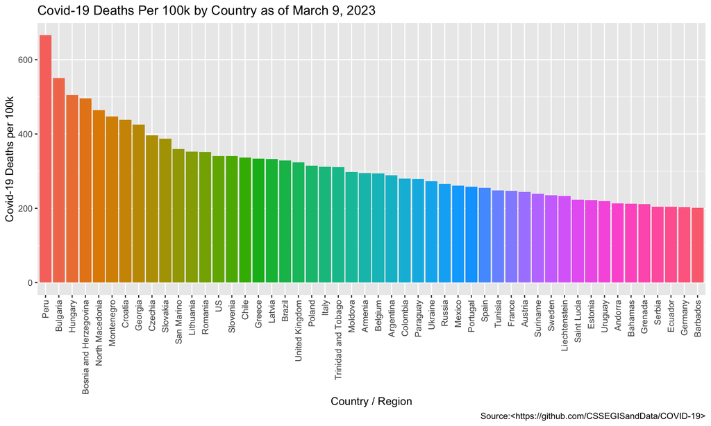

```r
country_pc_deaths_plot
```

As you can see there is a significant difference between which countries rank high in total number of cases versus total number of deaths. This could be because of a number of reasons; *1:* Access to healthcare, *2:* Vaccine roll-out differences, *3:* Covid-19 reporting differences, and so on.

For instance from these graphs we can see:

- Peru leads the mortality rate but is not in the top 50 of number cases. That tells us that Peruvians who got Covid-19 had a higher probability of succumbing to the disease when compared to other countries.
- Austria while number 2 in total cases is fairly low in deaths in this top 50 list.
- San Marino, while a very small country, reports ~ 2/3 of their population in total number of cases.
- Iceland and South Korea both place high in number of total cases but don’t show up in the top 50 in deaths per 100,000.

**This leads me to wonder what the distribution of countries might look like if we graph Total Deaths / Total Cases. This would give us the ratio of people who** **died per case, giving us an interesting perspective about how each country/region responded to Covid-19.**

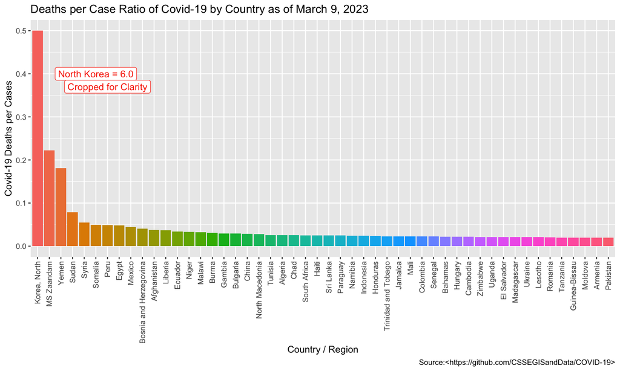

```r
country_deaths_per_case <- arrange(country_totals, desc(country_totals$Deaths_Per_Case))
country_deaths_per_case$Country_Region <- fct_inorder(country_deaths_per_case$Country_Region)

# Mutate North Korea to fit on graph for easier viewing of others
country_deaths_per_case <- country_deaths_per_case %>%
        mutate(Deaths_Per_Case = ifelse(Deaths_Per_Case > 0.5, 0.5, Deaths_Per_Case))

country_deaths_per_case_plot <- country_deaths_per_case[1:50, ] %>%
   ggplot(., aes(x = Country_Region, y = Deaths_Per_Case, fill = Country_Region)) +
   geom_bar(stat = 'identity', show.legend = FALSE) +
   ylim(0, 0.5) +
   annotate('label', x = 6, y = 0.4, angle = 90, color = '#f92f07', label = 'North Korea = 6.0') +
   annotate('label', x = 7, y = 0.37, angle = 90, color = '#f92f07', label = 'Cropped for Clarity') +
   theme(axis.text.x = element_text(angle = 90, vjust = 0.5, hjust = 1)) +
   labs(title = 'Deaths per Case Ratio of Covid-19 by Country as of March 9, 2023',
        x = 'Country / Region', y = 'Covid-19 Deaths per Cases',
        caption = 'Source:<https://github.com/CSSEGISandData/COVID-19>')

country_deaths_per_case_plot
```

*Note: North Korea was changed to fit in this graph for easier viewing of the remaining data. N.Korea = 6.0*

- According to this data you have a 600% chance of dying if you caught Covid-19 in North Korea. Clearly this is impossible and looking into this further we see they reported 6 deaths and 1 case, obviously this is not a reliable source for North Korea Covid-19 data.
- MS Zaandam was a cruise ship with unfortunate timing undocking in March 2020 making news headlines when 9 cases developed resulting in 2 deaths.
- Yemen had a very high mortality rate.
- Sudan and Syria both had above average mortality rates.
- Further on we see Peru near the top which confirms our previous hypothesis when looking at total number of deaths graph.

### US Data

Let’s utilize the location data to graph on a map of the US.

**Specifically I’d like to see the deaths per 100,000 organized by county.**

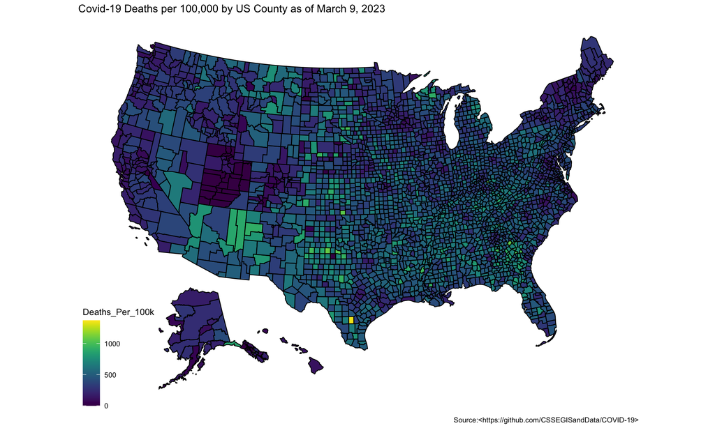

```r
options(dplyr.summarise.inform = FALSE)
us_counties_totals <- us_data %>%
    group_by(fips, County, Province_State) %>%
    summarize(Cases = max(Cases, na.rm = TRUE),
        Deaths = max(Deaths, na.rm = TRUE),
        Population = max(Population, na.rm = TRUE),
        Lat = median(Lat, na.rm = TRUE),
        Long = median(Long, na.rm = TRUE),
        Deaths_Per_100k = max(Deaths, na.rm = TRUE) / (max(Population, na.rm = TRUE) / 100000))
us_counties_totals[us_counties_totals == 'Inf'] <- 0

plot_usmap(regions = 'counties', data = filter(us_counties_totals, County != ''), values = 'Deaths_Per_100k') +
    scale_fill_viridis() +
    labs(title = 'Covid-19 Deaths per 100,000 by US County as of March 9, 2023',
        caption = 'Source:<https://github.com/CSSEGISandData/COVID-19>')
```

- With some exceptions it looks like more rural areas were prone to Covid-19 deaths when compared to more urban areas (e.g. no large cities are highlighted here - NYC, Chicago, nothing in California, etc).

**We can see a large yellow county south of San Antonio, Texas let’s investigate that. It should be one of the top listings so I will output the top five counties in deaths per 100,000**

```r
head(arrange(us_counties_totals, desc(Deaths_Per_100k)))
```

```
## # A tibble: 6 × 9
## # Groups:   fips, County [6]
##    fips County    Province_State Cases Deaths Population   Lat   Long
##   <dbl> <fct>     <fct>          <int>  <int>      <int> <dbl>  <dbl>
## 1 51640 Galax     Virginia        3293     87       6347  36.7  -80.9
## 2 48311 McMullen  Texas            186     10        743  28.4  -98.6
## 3 21201 Robertson Kentucky         879     23       2108  38.5  -84.1
## 4 48345 Motley    Texas            325     13       1200  34.1 -101.
## 5 13141 Hancock   Georgia         1945     91       8457  33.3  -83.0
## 6 51595 Emporia   Virginia        1660     57       5346  36.7  -77.5
## # ℹ 1 more variable: Deaths_Per_100k <dbl>
```

McMullen county has a small population for its size with 743 people, 186 total cases, and 10 deaths which is indeed a high proportion of deaths per capita so this makes sense.

## Modelling Pre-Vaccine Data

**From here I think it would be interesting to develop a model trained on data from the beginning of Covid reporting (January, 22, 2020)** **until the first Covid-19 vaccine was given in the US (December, 15, 2020). With this model trained and fitted with data pre-vaccine we will then forecast the death rate per day as if the vaccine was not developed.**

First we will create a new feature to show deaths per day for the whole dataset (reversing the cumulative sum) and plot it to give us something to compare our forecasting model to.

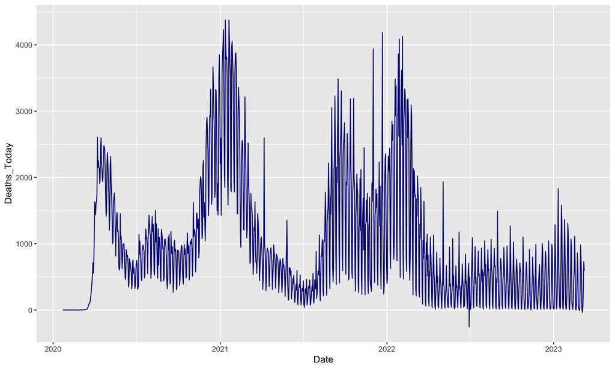

```r
# Create a dataframe consolidating each date's data in the US
time_series_us <- us_data %>%
    group_by(Date) %>%
    summarize(Cases = sum(Cases),
        Deaths = sum(Deaths)) %>%
        mutate(Deaths_Today = Deaths - lag(Deaths, default = first(Deaths)),
            Cases_Today = Cases - lag(Cases, default = first(Cases)))

# Plot the deaths per day
ggplot(time_series_us) +
    geom_line(aes(x = Date, y = Deaths_Today), color = 'darkblue')
```

- The mortality rate trended down summer of 2021, possibly because of the vaccine.
- There is a large spike in 2021 too early for it to be related to winter, but maybe from the spread of new Covid-19 variants.
- The 2021-2022 winter spike is lower than 2020-2021’s, but still present. Perhaps this is because there was still a decent portion of the population that were unvaccinated.
- There is a high amount of seasonality frequency to this data.
- 2023 breaks all trends and stays fairly low and stable.
- The seasonality will be difficult to model because the vaccine came out so quickly meaning we only see a portion of the seasonality (less than 1 year) occur pre-vaccine and thus the data our model to train on will be sparse in this sense.

**Let’s begin building the model and train it only on data from January, 22, 2020 to December, 15, 2020.**

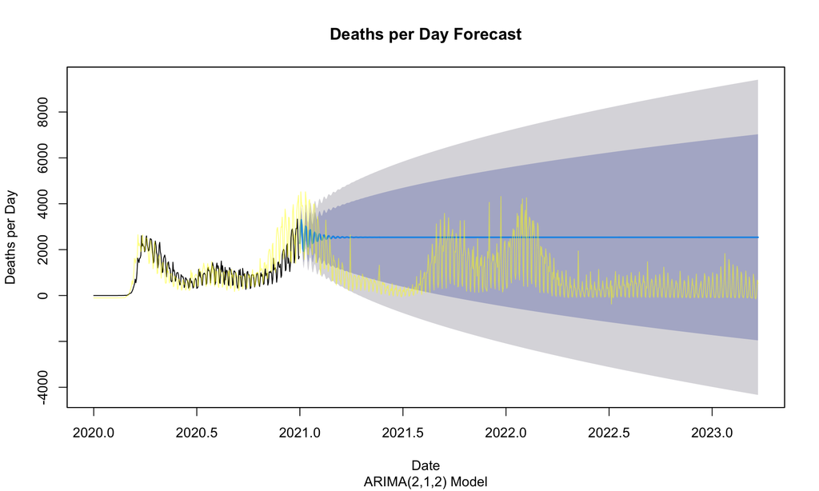

```r
# Filter data to only include pre-vaccine dates
pre_vaccine_us <- filter(time_series_us, Date < '2020-12-15')
pre_vaccine_us <- pre_vaccine_us %>%
    select(-c(Cases, Deaths, Cases_Today))

# Build model with frequency matching the seasonality
data_ts <- ts(pre_vaccine_us, start = c(2020,1,22), frequency = 328)
fit <- auto.arima(data_ts[, 2])
# Predict 2 years into the future from 2020-12-15
forecast_no_vaccine <- forecast(fit, 365*2)

plot(forecast_no_vaccine,
    xlab = 'Date',
    ylab = 'Deaths per Day',
    main = 'Deaths per Day Forecast',
    sub = 'ARIMA(2,1,2) Model')

# Plot the acutal data on top of the forecast model
par(new = TRUE)
plot(time_series_us$Date, time_series_us$Deaths_Today,
    col = rgb(red = 1, blue = 0, green = 1, alpha = 0.5),
    type = 'l',
    lty = 1,
    ylim = c(-4000, 9000),
    xlab = '',
    ylab = '',
    xaxt = 'n',
    yaxt = 'n')
```

*Note: The black line is the REAL data, and the blue/grey is the PREDICTED data.* *The second yellow line is the REAL data overlaid to compare to the prediction region.*

- We can see that it didn’t capture the seasonality well but it still gives a great prediction cone that rises much further than reality.
- The prediction forecasting shows deaths per day could have risen to ~5000 by 2022 and ~6000 by 2023.
- Interesting to see how flat deaths per day is from Spring of 2022 on towards present day, especially compared to this forecasting model’s alternate world.

Potential problems with this model:

- As was mentioned before the training data in this case is too short to capture proper seasonality to set the frequency hyperparameter. Aggregating from days to weeks might help a little but would only serve to smooth the daily reporting noise.
- It doesn’t account for mutating Covid-19 strains (e.g. omicron and delta variants arouse in mid and late 2021).
- Arguably you could extend the training set to cut off when a certain percentage of the population received the vaccine or maybe the 2nd dose. As rollout in December of 2020 was strictly healthcare workers, immunosuppressed, and the elderly its effects were not seen for quite some time when more doses were available.

## Conclusion

This dataset presents a wealth of information that we’ve only scratched the surface of here. The strife, efforts, and successes of the world to tackle this issue really come to the surface during analysis of this data.

Some key takeaways that were noted from above:

- Total number of cases did not necessarily correlate heavily towards total number of deaths (or deaths per capita). This likely points towards differences in country’s access to healthcare, vaccines, or Covid-19 response.
- Some countries did not report Covid-19 statistics to the same effort as most of the world (e.g. North Korea)
- Yemen, Sudan, Syria, Somalia, and Peru (and many, many others) saw a large ratio of deaths per case.
- In the US many large metropolitan areas/counties ranked low in deaths per 100,000 people, when comparing all US counties.
- Perhaps as expected, Covid cases had a seasonal frequency to them, spiking in the cooler months.
- The vaccines effectively tamped down deaths but took ~1 year from their release to show up in the data consistently (though there was a noticeable dip in the summer of 2021 compared to the summer of 2020).

## Bias Acknowledgment

During this analysis I was intentional with my decisions to ensure I stepped through this dataset with an unbiased lense. However, it must be stated that from the beginning of the pandemic and until recently, I worked in several major metropolitan hospitals, which gave me a unique perspective into the Covid-19 pandemic and how the public handled it. Another bias I possess is that I’ve been relatively healthy my whole life. I may not be able to pinpoint how this may have affected my analysis here, but it undoubtedly did. Hopefully I’ve mitigated those effects and presented valid inferences.

In my opinion there is also certainly a large amount of bias from within this dataset itself by way of the hundreds of different sources it took to compile this data - sources coming from different countries, US states, and counties all of which having different reporting standards, diagnosis metrics, and political motivations that may have skewed their Covid-19 reporting.